# Graphics

## ggplot2 - plot composition - 1

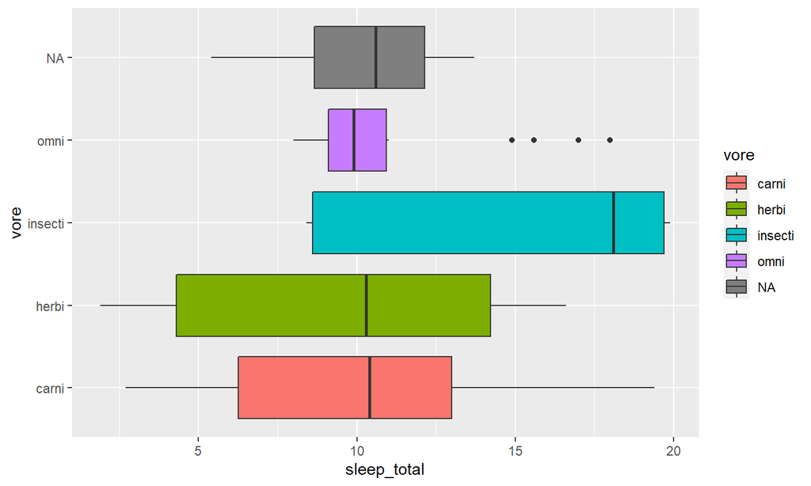

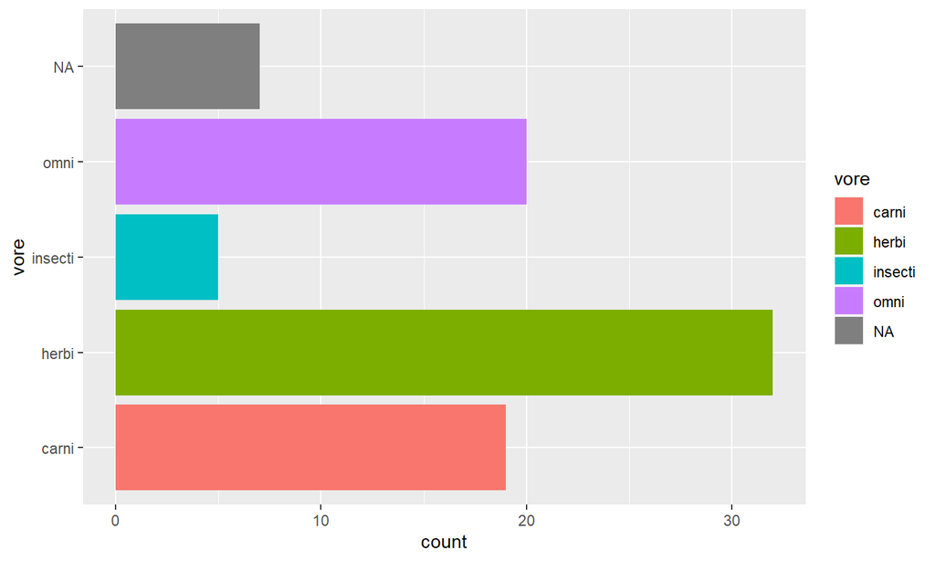

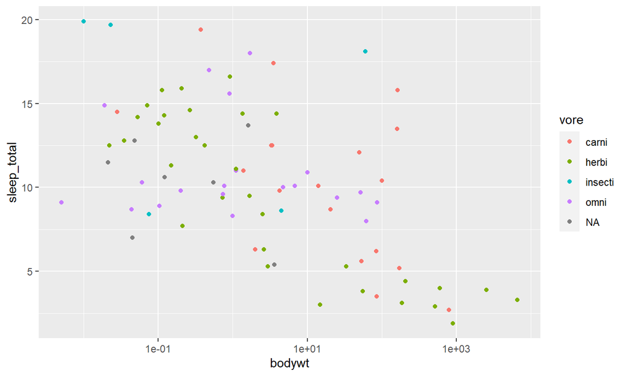

## ggplot2 - plot composition - 2

- combining them with patchwork is a breeze using the different operators

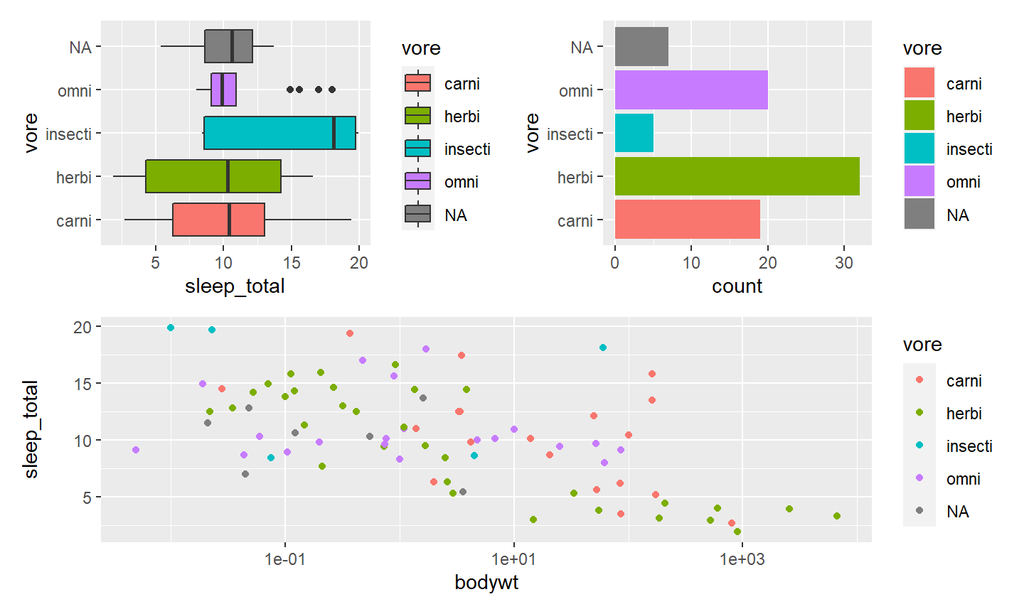

```r
(p1 | p2) /
   p3
```

## ggplot2 - plot composition - 3

- combining them with patchwork is a breeze using the different operators
- plot_layout(guides = ‘collect’) collects the legends

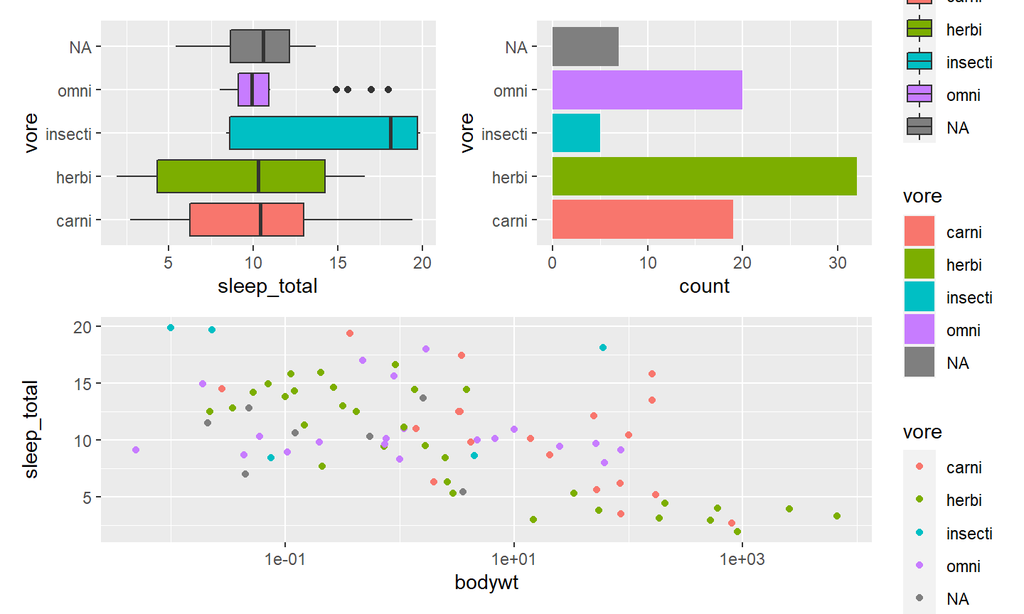

```r
p_all <- (p1 | p2) /
            p3
p_all + plot_layout(guides = 'collect')
```

## Lab

Patchwork will assign the same amount of space to each plot by default, but this can be controlled with the `widths` and `heights` argument in `plot_layout()`. This can take a numeric vector giving their relative sizes (e.g. `c(2, 1)` will make the first plot twice as big as the second). Modify the code below so that the middle plot takes up half of the total space:

```
p <- ggplot(mtcars) +
  geom_point(aes(x = disp, y = mpg))
p + p + p
```

## ggplot2 - animation - 1

- gganimate package
- gganimate extends the API and grammar to describe animations
- many different transitions that control how data is interpreted for animation

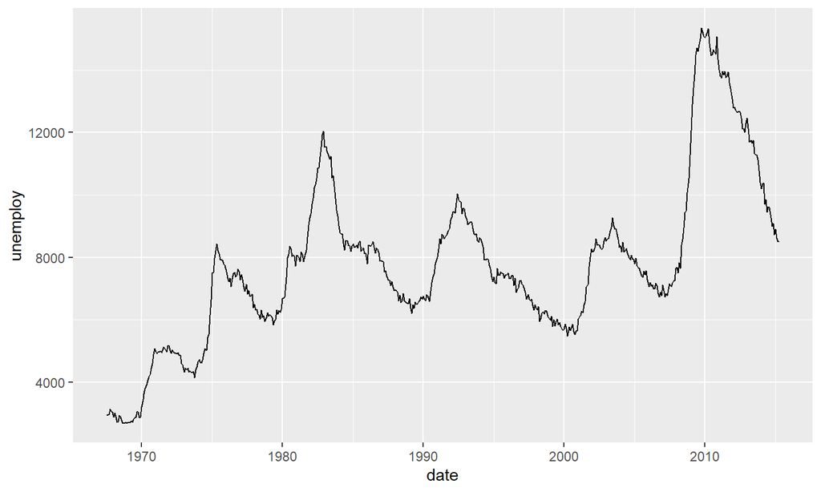

```r
ggplot(economics) +
  geom_line(aes(x = date, y = unemploy))
```

## ggplot2 - animation - 2

- transition_reveal: reveal data along a given dimension

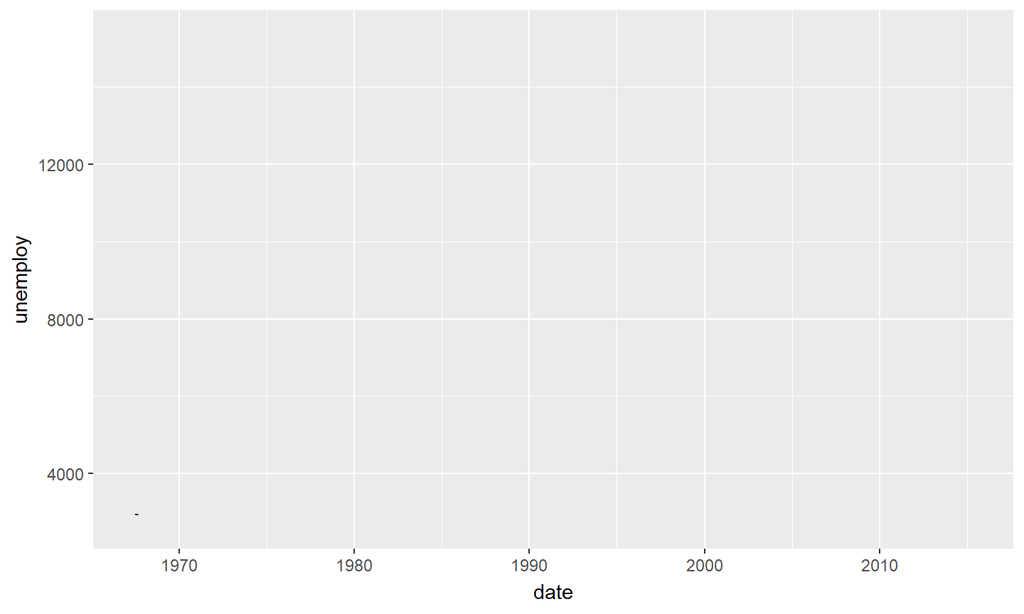

```r
ggplot(economics) +
  geom_line(aes(x = date, y = unemploy)) +
  transition_reveal(along = date)
```

## ggplot2 - animation - 3

- transition_states: transition between several distinct stages of the data

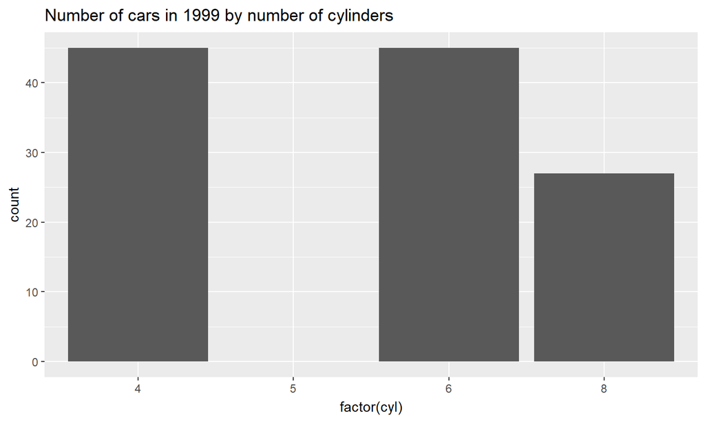

```r
ggplot(mpg) + geom_bar(aes(x = factor(cyl))) +
  labs(title = 'Number of cars in {closest_state} by number of cylinders') +
  transition_states(states = year) + enter_grow() +
  exit_fade()
```

## Lab

In the animation below (as in all the other animations) the changes happens at constant speed. How values change during an animation is called easing and can be controlled using the `ease_aes()` function. Read the documentation for `ease_aes()` and experiment with different easings in the animation, i.e. ease_aes(“bounce-in-out”)

```
mpg2 <- tidyr::pivot_longer(mpg, c(cty,hwy))
ggplot(mpg2) +
  geom_point(aes(x = displ, y = value)) +
  ggtitle("{if (closest_state == 'cty') 'Efficiency in city' else 'Efficiency on highway'}") +
  transition_states(name)
```